# Analysis

## Solution outline

- Outlier analysis and decide to continue or drop
- Pca + plots and use this for further analysis
- K-means + plots
- Categorize countries based on 3 variables [gdpp, child_mort, income]

## Importing base libraries

```python
import pandas as pd
import numpy as np
import matplotlib.pyplot as plt
import seaborn as sns
from sklearn.decomposition import PCA
from sklearn.model_selection import train_test_split
import sklearn
from sklearn.preprocessing import StandardScaler
from sklearn.cluster import KMeans
from sklearn.metrics import silhouette_score
from scipy.cluster.hierarchy import linkage
from scipy.cluster.hierarchy import dendrogram
from scipy.cluster.hierarchy import cut_tree
```

## Exploring the data

```python
country_df = pd.read_csv("./data/country-data.csv")

country_df.head()
```

|  | country | child_mort | exports | health | imports | income | inflation | life_expec | total_fer | gdpp |
| --- | --- | --- | --- | --- | --- | --- | --- | --- | --- | --- |
| 0 | Afghanistan | 90.2 | 10.0 | 7.58 | 44.9 | 1610 | 9.44 | 56.2 | 5.82 | 553 |
| 1 | Albania | 16.6 | 28.0 | 6.55 | 48.6 | 9930 | 4.49 | 76.3 | 1.65 | 4090 |
| 2 | Algeria | 27.3 | 38.4 | 4.17 | 31.4 | 12900 | 16.10 | 76.5 | 2.89 | 4460 |
| 3 | Angola | 119.0 | 62.3 | 2.85 | 42.9 | 5900 | 22.40 | 60.1 | 6.16 | 3530 |
| 4 | Antigua and Barbuda | 10.3 | 45.5 | 6.03 | 58.9 | 19100 | 1.44 | 76.8 | 2.13 | 12200 |

```python
country_df.columns
```

```
Index(['country', 'child_mort', 'exports', 'health', 'imports', 'income',
       'inflation', 'life_expec', 'total_fer', 'gdpp'],
      dtype='object')
```

```python
country_df.shape
```

```
(167, 10)
```

```python
country_df.describe(percentiles=[.25,.5,.75,.90,.95,.99])
```

|  | child_mort | exports | health | imports | income | inflation | life_expec | total_fer | gdpp |
| --- | --- | --- | --- | --- | --- | --- | --- | --- | --- |
| count | 167.000000 | 167.000000 | 167.000000 | 167.000000 | 167.000000 | 167.000000 | 167.000000 | 167.000000 | 167.000000 |
| mean | 38.270060 | 41.108976 | 6.815689 | 46.890215 | 17144.688623 | 7.781832 | 70.555689 | 2.947964 | 12964.155689 |
| std | 40.328931 | 27.412010 | 2.746837 | 24.209589 | 19278.067698 | 10.570704 | 8.893172 | 1.513848 | 18328.704809 |
| min | 2.600000 | 0.109000 | 1.810000 | 0.065900 | 609.000000 | -4.210000 | 32.100000 | 1.150000 | 231.000000 |
| 25% | 8.250000 | 23.800000 | 4.920000 | 30.200000 | 3355.000000 | 1.810000 | 65.300000 | 1.795000 | 1330.000000 |
| 50% | 19.300000 | 35.000000 | 6.320000 | 43.300000 | 9960.000000 | 5.390000 | 73.100000 | 2.410000 | 4660.000000 |
| 75% | 62.100000 | 51.350000 | 8.600000 | 58.750000 | 22800.000000 | 10.750000 | 76.800000 | 3.880000 | 14050.000000 |
| 90% | 100.220000 | 70.800000 | 10.940000 | 75.420000 | 41220.000000 | 16.640000 | 80.400000 | 5.322000 | 41840.000000 |
| 95% | 116.000000 | 80.570000 | 11.570000 | 81.140000 | 48290.000000 | 20.870000 | 81.400000 | 5.861000 | 48610.000000 |
| 99% | 153.400000 | 160.480000 | 13.474000 | 146.080000 | 84374.000000 | 41.478000 | 82.370000 | 6.563600 | 79088.000000 |
| max | 208.000000 | 200.000000 | 17.900000 | 174.000000 | 125000.000000 | 104.000000 | 82.800000 | 7.490000 | 105000.000000 |

```python
country_df_numerical_values = country_df.drop(['country'], axis=1)
country_df_numerical_values.head()
```

|  | child_mort | exports | health | imports | income | inflation | life_expec | total_fer | gdpp |
| --- | --- | --- | --- | --- | --- | --- | --- | --- | --- |
| 0 | 90.2 | 10.0 | 7.58 | 44.9 | 1610 | 9.44 | 56.2 | 5.82 | 553 |
| 1 | 16.6 | 28.0 | 6.55 | 48.6 | 9930 | 4.49 | 76.3 | 1.65 | 4090 |
| 2 | 27.3 | 38.4 | 4.17 | 31.4 | 12900 | 16.10 | 76.5 | 2.89 | 4460 |
| 3 | 119.0 | 62.3 | 2.85 | 42.9 | 5900 | 22.40 | 60.1 | 6.16 | 3530 |
| 4 | 10.3 | 45.5 | 6.03 | 58.9 | 19100 | 1.44 | 76.8 | 2.13 | 12200 |

## Outlier Detection via IQR Method

```python
#IQR method:
Q1 = country_df_numerical_values.quantile(0.25)
Q1
```

```
child_mort       8.250
exports         23.800
health           4.920
imports         30.200
income        3355.000
inflation        1.810
life_expec      65.300
total_fer        1.795
gdpp          1330.000
Name: 0.25, dtype: float64
```

```python
Q3 = country_df_numerical_values.quantile(0.75)
Q3
```

```
child_mort       62.10
exports          51.35
health            8.60
imports          58.75
income        22800.00
inflation        10.75
life_expec       76.80
total_fer         3.88
gdpp          14050.00
Name: 0.75, dtype: float64
```

```python
IQR = Q3 - Q1
IQR
```

```
child_mort       53.850
exports          27.550
health            3.680
imports          28.550
income        19445.000
inflation         8.940
life_expec       11.500
total_fer         2.085
gdpp          12720.000
dtype: float64
```

### Normalizing the dataset

```python
normalization_df=(country_df_numerical_values < (Q1 - 1.5 * IQR)) | (country_df_numerical_values > (Q3 + 1.5 * IQR))
normalization_df.head()
```

|  | child_mort | exports | health | imports | income | inflation | life_expec | total_fer | gdpp |
| --- | --- | --- | --- | --- | --- | --- | --- | --- | --- |
| 0 | False | False | False | False | False | False | False | False | False |
| 1 | False | False | False | False | False | False | False | False | False |
| 2 | False | False | False | False | False | False | False | False | False |
| 3 | False | False | False | False | False | False | False | False | False |
| 4 | False | False | False | False | False | False | False | False | False |

```python
normalization_df.info()
```

```
<class 'pandas.core.frame.DataFrame'>
RangeIndex: 167 entries, 0 to 166
Data columns (total 9 columns):
child_mort    167 non-null bool
exports       167 non-null bool
health        167 non-null bool
imports       167 non-null bool
income        167 non-null bool
inflation     167 non-null bool
life_expec    167 non-null bool
total_fer     167 non-null bool
gdpp          167 non-null bool
dtypes: bool(9)
memory usage: 1.6 KB
```

```python
country_df_normalized = country_df[~normalization_df.any(axis=1)]
country_df_normalized.head()
```

|  | country | child_mort | exports | health | imports | income | inflation | life_expec | total_fer | gdpp |
| --- | --- | --- | --- | --- | --- | --- | --- | --- | --- | --- |
| 0 | Afghanistan | 90.2 | 10.0 | 7.58 | 44.9 | 1610 | 9.44 | 56.2 | 5.82 | 553 |
| 1 | Albania | 16.6 | 28.0 | 6.55 | 48.6 | 9930 | 4.49 | 76.3 | 1.65 | 4090 |
| 2 | Algeria | 27.3 | 38.4 | 4.17 | 31.4 | 12900 | 16.10 | 76.5 | 2.89 | 4460 |
| 3 | Angola | 119.0 | 62.3 | 2.85 | 42.9 | 5900 | 22.40 | 60.1 | 6.16 | 3530 |
| 4 | Antigua and Barbuda | 10.3 | 45.5 | 6.03 | 58.9 | 19100 | 1.44 | 76.8 | 2.13 | 12200 |

```python
country_df_normalized.info()
```

```
<class 'pandas.core.frame.DataFrame'>
Int64Index: 128 entries, 0 to 166
Data columns (total 10 columns):
country       128 non-null object
child_mort    128 non-null float64
exports       128 non-null float64
health        128 non-null float64
imports       128 non-null float64
income        128 non-null int64
inflation     128 non-null float64
life_expec    128 non-null float64
total_fer     128 non-null float64
gdpp          128 non-null int64
dtypes: float64(7), int64(2), object(1)
memory usage: 11.0+ KB
```

## We'll conduct a basic Univariate analysis on the normalized dataset to see the distributions of the features for various countries.

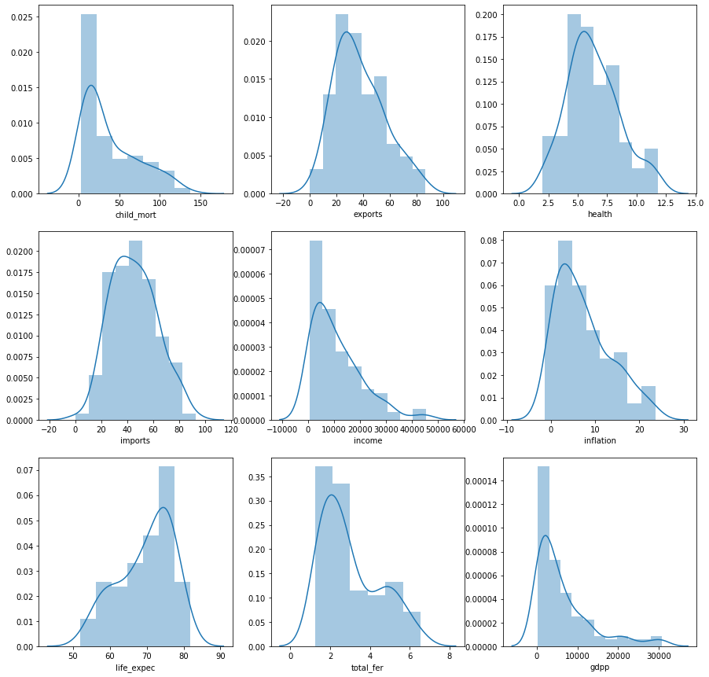

```python
# Univariate Analysis:
f, ax = plt.subplots(3,3, figsize=(15, 15))
sns.distplot(country_df_normalized['child_mort'].dropna(), kde=True, ax=ax[0,0])
sns.distplot(country_df_normalized['exports'].dropna(), kde=True, ax=ax[0,1])
sns.distplot(country_df_normalized['health'].dropna(), kde=True, ax=ax[0,2])
sns.distplot(country_df_normalized['imports'].dropna(), kde=True, ax=ax[1,0])
sns.distplot(country_df_normalized['income'].dropna(), kde=True, ax=ax[1,1])
sns.distplot(country_df_normalized['inflation'].dropna(), kde=True, ax=ax[1,2])
sns.distplot(country_df_normalized['life_expec'].dropna(), kde=True, ax=ax[2,0])
sns.distplot(country_df_normalized['total_fer'].dropna(), kde=True, ax=ax[2,1])
sns.distplot(country_df_normalized['gdpp'].dropna(), kde=True, ax=ax[2,2])
```

## Inferences from the `Univariate Analysis`

### Features which follow roughly a normal distributions

- exports
- health
- imports

### Features which do not follow roughly a normal distributions

- child_mort
- income
- inflation
- life_expec
- total_fer
- gdpp

## Moving further with a `Bivariate Analysis` to better understand how the various featuers are correlated to each other.

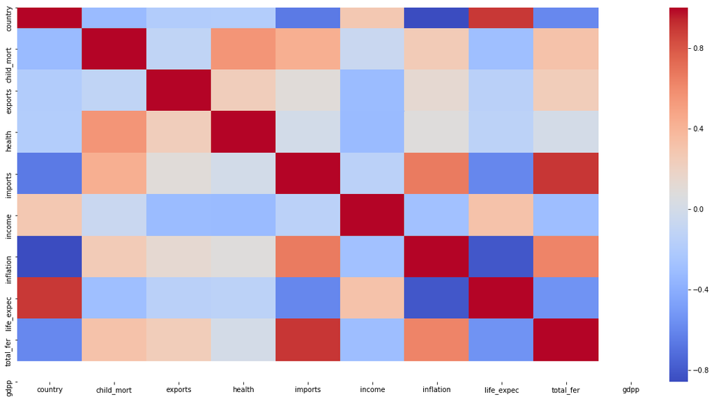

```python
%matplotlib inline
plt.figure(figsize = (20,10))

df = np.corrcoef(country_df_normalized.drop(['country'], axis=1).transpose())

sns.heatmap(df, \
            cmap='coolwarm', \
            xticklabels=country_df_normalized.columns, \
            yticklabels=country_df_normalized.columns)
```

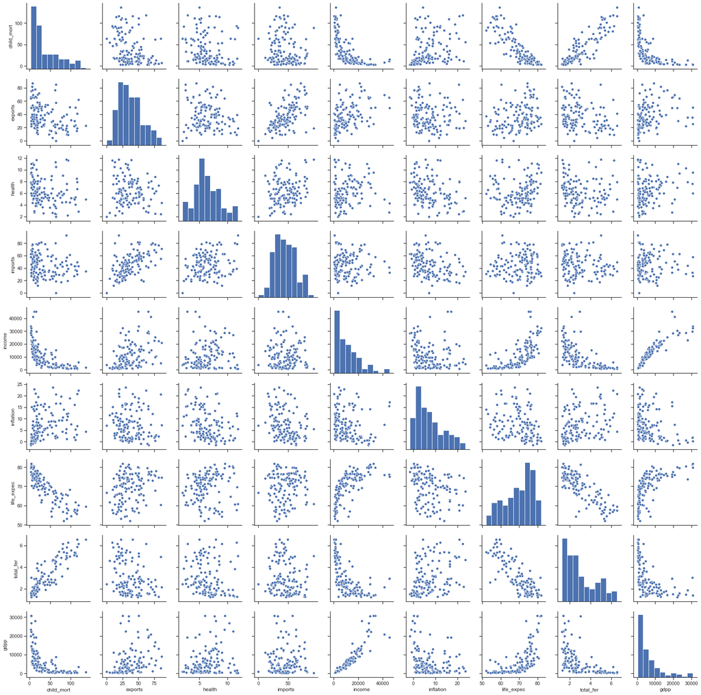

```python
# Bivariate Analysis:

sns.set(style="ticks", color_codes=True)

sns.pairplot(country_df_normalized)
```

## Inferences from the `Bivariate Analysis`

- income and gdpp
- imports and exports
- child_mort and life_expec

## Principal Component Analysis

```python
df = country_df_normalized.drop(['country'],axis=1)


# Putting feature variable to X
X = df.drop(['income', 'gdpp'],axis=1)

# Putting response variable to y
y = df['gdpp']
```

### Splitting the data into `test` and `train` and exploring the components formed via `PCA` method

```python
X_train, X_test, y_train, y_test = train_test_split(X,y, \
                                                    train_size=0.7, \
                                                    test_size=0.3, \
                                                    random_state=100)
```

### Create a dataframe wrt the identified Priciple components

```python
pca = PCA(svd_solver='randomized', random_state=16)

pca.fit(X_train)

pca.components_
```

```
array([[ 9.32799511e-01, -2.43171494e-01, -1.65648669e-02,
        -1.94230923e-01,  6.17559847e-02, -1.66347215e-01,
         3.56013165e-02],
       [ 3.01640278e-01,  7.38443890e-01, -1.45742355e-02,
         5.97833614e-01,  2.17928470e-02, -7.41589948e-02,
         1.10381955e-02],
       [ 5.95693557e-03, -6.12292213e-01,  7.31233529e-02,
         7.57597353e-01, -2.09846408e-01, -4.15365777e-02,
        -1.08842620e-03],
       [-9.75053823e-02, -1.31794324e-01, -4.32139576e-02,
         1.54533956e-01,  9.58145264e-01, -1.69888249e-01,
         2.16887637e-02],
       [ 1.66106525e-01, -3.76044277e-02, -7.32549945e-02,
         7.47676187e-02,  1.67880843e-01,  9.65182711e-01,
        -1.66251430e-02],
       [ 2.72608230e-02,  4.33577690e-02,  9.93404460e-01,
        -3.80034486e-02,  7.06636654e-02,  6.32120319e-02,
         9.54740176e-03],
       [-3.19515462e-02,  1.66087691e-03, -8.94482726e-03,
        -6.06008444e-04, -2.13559563e-02,  2.58518284e-02,
         9.98885163e-01]])
```

```python
colnames = list(X_train.columns)

pcs_df = pd.DataFrame({'PC1':pca.components_[0],\
                       'PC2':pca.components_[1], \
                       'Feature':colnames})

pcs_df.head()
```

|  | PC1 | PC2 | Feature |
| --- | --- | --- | --- |
| 0 | 0.932800 | 0.301640 | child_mort |
| 1 | -0.243171 | 0.738444 | exports |
| 2 | -0.016565 | -0.014574 | health |
| 3 | -0.194231 | 0.597834 | imports |
| 4 | 0.061756 | 0.021793 | inflation |

```python
explained_variance_ratio_ = np.around(pca.explained_variance_ratio_, decimals = 3)
explained_variance_ratio_
```

```
array([0.662, 0.228, 0.086, 0.017, 0.006, 0.002, 0.   ])
```

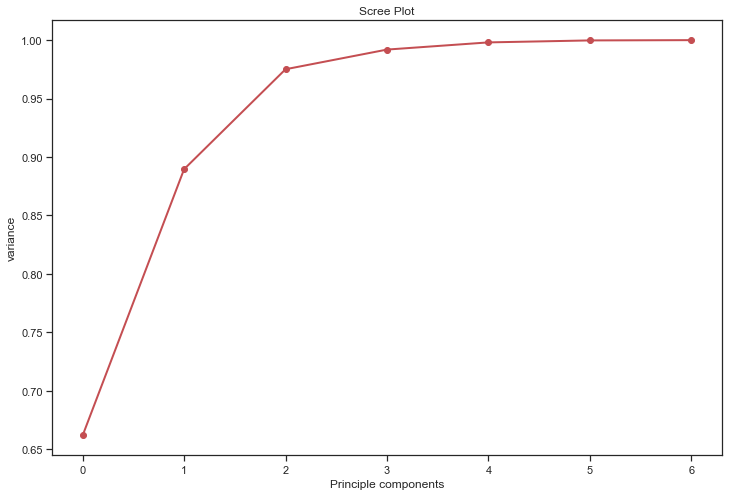

```python
# scree plot
%matplotlib inline

fig = plt.figure(figsize = (12,8))
plt.plot(np.cumsum(pca.explained_variance_ratio_), 'ro-', linewidth=2)
plt.title('Scree Plot')
plt.xlabel('Principle components')
plt.ylabel('variance')
plt.show()
```

```python
from sklearn.decomposition import IncrementalPCA
pca_final = IncrementalPCA(n_components=2)

df_pca = pca_final.fit_transform(country_df_normalized.drop(['country'], axis=1))
df_pca.shape
```

```
(128, 2)
```

```python
pc = np.transpose(df_pca)

pc_df = pd.DataFrame({'PC1':pc[0],'PC2':pc[1]})
pc_df.head()
```

|  | PC1 | PC2 |
| --- | --- | --- |
| 0 | -11180.166271 | 713.612481 |
| 1 | -2344.882463 | -1202.984225 |
| 2 | 293.568386 | -2615.883024 |
| 3 | -5958.659572 | 666.908524 |
| 4 | 9824.835581 | 123.265885 |

```python
pc_df.info()
```

```
<class 'pandas.core.frame.DataFrame'>
RangeIndex: 128 entries, 0 to 127
Data columns (total 2 columns):
PC1    128 non-null float64
PC2    128 non-null float64
dtypes: float64(2)
memory usage: 2.1 KB
```

```python
pc_df.index = country_df_normalized['country']
pc_df.head()
```

| country | PC1 | PC2 |
| --- | --- | --- |
| Afghanistan | -11180.166271 | 713.612481 |
| Albania | -2344.882463 | -1202.984225 |
| Algeria | 293.568386 | -2615.883024 |
| Angola | -5958.659572 | 666.908524 |
| Antigua and Barbuda | 9824.835581 | 123.265885 |

```
'c' argument looks like a single numeric RGB or RGBA sequence, which should be avoided as value-mapping will have precedence in case its length matches with 'x' & 'y'.  Please use a 2-D array with a single row if you really want to specify the same RGB or RGBA value for all points.
```

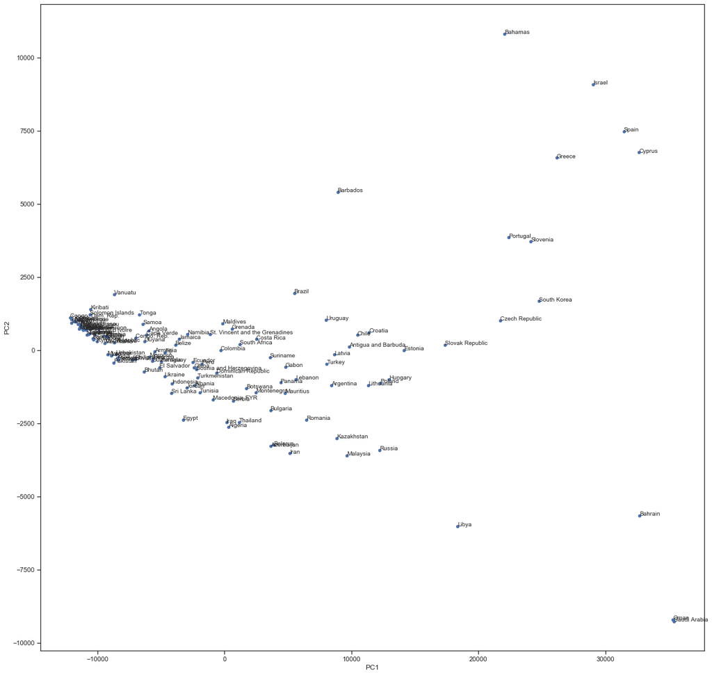

```python
%matplotlib inline

ax = pc_df.plot(kind='scatter', x='PC1', y='PC2', figsize=(20,20))

for i, country in enumerate(pc_df.index):
    ax.annotate(country, (pc_df.iloc[i].PC1, pc_df.iloc[i].PC2))
```

## Clustering via k-means

```python
from sklearn.neighbors import NearestNeighbors
from random import sample
from numpy.random import uniform
import numpy as np
from math import isnan

# Defining a hopkins function to check the suitability of the data.
def hopkins(X):
    d = X.shape[1]

    n = len(X)
    m = int(0.1 * n)
    nbrs = NearestNeighbors(n_neighbors=1).fit(X.values)

    rand_X = sample(range(0, n, 1), m)

    ujd = []
    wjd = []
    for j in range(0, m):
        u_dist, _ = nbrs.kneighbors(uniform(np.amin(X,axis=0),np.amax(X,axis=0),d).reshape(1, -1), 2, return_distance=True)
        ujd.append(u_dist[0][1])
        w_dist, _ = nbrs.kneighbors(X.iloc[rand_X[j]].values.reshape(1, -1), 2, return_distance=True)
        wjd.append(w_dist[0][1])

    H = sum(ujd) / (sum(ujd) + sum(wjd))
    if isnan(H):
        print(ujd, wjd)
        H = 0

    return H
```

```python
pc_df.head()
```

| country | PC1 | PC2 |
| --- | --- | --- |
| Afghanistan | -11180.166271 | 713.612481 |
| Albania | -2344.882463 | -1202.984225 |
| Algeria | 293.568386 | -2615.883024 |
| Angola | -5958.659572 | 666.908524 |
| Antigua and Barbuda | 9824.835581 | 123.265885 |

```python
print('With ',round(hopkins(pc_df),2),'hopkins statistic it is indicating data is nicely clustered')
```

```
With  0.81 hopkins statistic it is indicating data is nicely clustered
```

```python
df_kmean = pc_df
df_kmean.head()
```

| country | PC1 | PC2 |
| --- | --- | --- |
| Afghanistan | -11180.166271 | 713.612481 |
| Albania | -2344.882463 | -1202.984225 |
| Algeria | 293.568386 | -2615.883024 |
| Angola | -5958.659572 | 666.908524 |
| Antigua and Barbuda | 9824.835581 | 123.265885 |

```python
from sklearn.metrics import silhouette_score
sse_ = []
for k in range(2, 10):
    kmeans = KMeans(n_clusters=k).fit(df_kmean)
    sse_.append([k, silhouette_score(df_kmean, kmeans.labels_)])
```

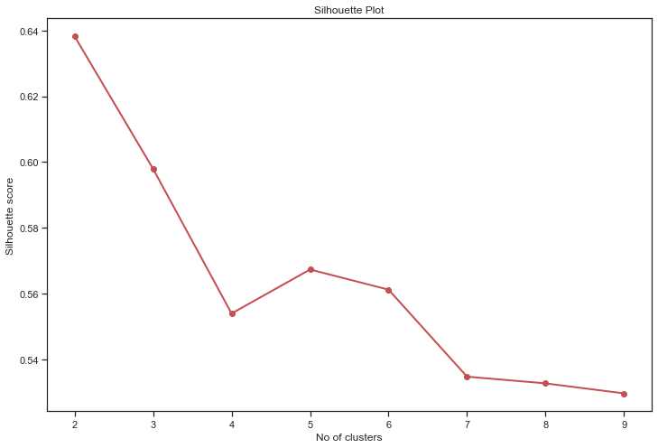

```python
fig = plt.figure(figsize = (12,8))
plt.plot(pd.DataFrame(sse_)[0], pd.DataFrame(sse_)[1], 'ro-', linewidth=2);
plt.title('Silhouette Plot')
plt.xlabel('No of clusters')
plt.ylabel('Silhouette score')
plt.show()
```

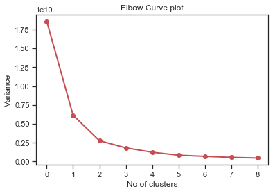

```python
# Elbow curve method

ssd = []
for num_clusters in list(range(1,10)):
    model_clus = KMeans(n_clusters = num_clusters, max_iter=50)
    model_clus.fit(df_kmean)
    ssd.append(model_clus.inertia_)


plt.plot(ssd, 'ro-', linewidth=2);
plt.title('Elbow Curve plot')
plt.xlabel('No of clusters')
plt.ylabel('Variance')
plt.show()
```

Starting with K=4

```python
kmean_model = KMeans(n_clusters = 4, max_iter=50,random_state = 50)
kmean_model.fit(df_kmean)
```

```
KMeans(algorithm='auto', copy_x=True, init='k-means++', max_iter=50,
       n_clusters=4, n_init=10, n_jobs=None, precompute_distances='auto',
       random_state=50, tol=0.0001, verbose=0)
```

```python
kmean2_df=df_kmean
kmean2_df.index = pd.RangeIndex(len(kmean2_df.index))
kmean2_df2 = pd.concat([kmean2_df, pd.Series(kmean_model.labels_)], axis=1)
kmean2_df2.columns = ['PC1', 'PC2','ClusterID']
kmean2_df2.head()
```

|  | PC1 | PC2 | ClusterID |
| --- | --- | --- | --- |
| 0 | -11180.166271 | 713.612481 | 3 |
| 1 | -2344.882463 | -1202.984225 | 1 |
| 2 | 293.568386 | -2615.883024 | 1 |
| 3 | -5958.659572 | 666.908524 | 3 |
| 4 | 9824.835581 | 123.265885 | 0 |

```python
kmean2_df2['ClusterID'].value_counts()
```

```
3    56
1    36
0    24
2    12
Name: ClusterID, dtype: int64
```

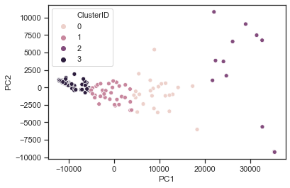

```python
sns.scatterplot(x='PC1',y='PC2',hue='ClusterID',legend='full',data=kmean2_df2)
```

```python
kmean_test2 = df_kmean
kmean_test2.head()
```

|  | PC1 | PC2 |
| --- | --- | --- |
| 0 | -11180.166271 | 713.612481 |
| 1 | -2344.882463 | -1202.984225 |
| 2 | 293.568386 | -2615.883024 |
| 3 | -5958.659572 | 666.908524 |
| 4 | 9824.835581 | 123.265885 |

### K-mean with K=3

```python
kmean_model2 = KMeans(n_clusters = 3, max_iter=50,random_state = 50)
kmean_model2.fit(kmean_test2)
```

```
KMeans(algorithm='auto', copy_x=True, init='k-means++', max_iter=50,
       n_clusters=3, n_init=10, n_jobs=None, precompute_distances='auto',
       random_state=50, tol=0.0001, verbose=0)
```

```python
kmean2_test_df=df_kmean
kmean2_test_df.index = pd.RangeIndex(len(kmean2_test_df.index))
kmean2_test2_df = pd.concat([kmean2_test_df, pd.Series(kmean_model2.labels_)], axis=1)
kmean2_test2_df.columns = ['PC1', 'PC2','ClusterID']
kmean2_test2_df.head()
```

|  | PC1 | PC2 | ClusterID |
| --- | --- | --- | --- |
| 0 | -11180.166271 | 713.612481 | 2 |
| 1 | -2344.882463 | -1202.984225 | 2 |
| 2 | 293.568386 | -2615.883024 | 0 |
| 3 | -5958.659572 | 666.908524 | 2 |
| 4 | 9824.835581 | 123.265885 | 0 |

```python
kmean2_test2_df['ClusterID'].value_counts()
```

```
2    74
0    40
1    14
Name: ClusterID, dtype: int64
```

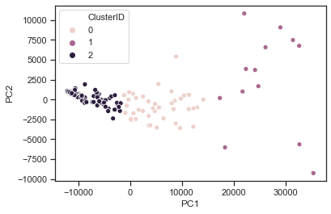

```python
sns.scatterplot(x='PC1',y='PC2',hue='ClusterID',legend='full',data=kmean2_test2_df)
```

### Merge K-mean dataset with original one and analyze the clusters to find out cluster representation of various features

```python
kmean2_test2_df['country'] = country_df_normalized['country']

kmean2_test2_df.head()
```

|  | PC1 | PC2 | ClusterID | country |
| --- | --- | --- | --- | --- |
| 0 | -11180.166271 | 713.612481 | 2 | Afghanistan |
| 1 | -2344.882463 | -1202.984225 | 2 | Albania |
| 2 | 293.568386 | -2615.883024 | 0 | Algeria |
| 3 | -5958.659572 | 666.908524 | 2 | Angola |
| 4 | 9824.835581 | 123.265885 | 0 | Antigua and Barbuda |

```python
kmean2_test2_df = pd.merge(kmean2_test2_df,country_df_normalized,on='country')
kmean2_test2_df.head()
```

|  | PC1 | PC2 | ClusterID | country | child_mort | exports | health | imports | income | inflation | life_expec | total_fer | gdpp |
| --- | --- | --- | --- | --- | --- | --- | --- | --- | --- | --- | --- | --- | --- |
| 0 | -11180.166271 | 713.612481 | 2 | Afghanistan | 90.2 | 10.0 | 7.58 | 44.9 | 1610 | 9.44 | 56.2 | 5.82 | 553 |
| 1 | -2344.882463 | -1202.984225 | 2 | Albania | 16.6 | 28.0 | 6.55 | 48.6 | 9930 | 4.49 | 76.3 | 1.65 | 4090 |
| 2 | 293.568386 | -2615.883024 | 0 | Algeria | 27.3 | 38.4 | 4.17 | 31.4 | 12900 | 16.10 | 76.5 | 2.89 | 4460 |
| 3 | -5958.659572 | 666.908524 | 2 | Angola | 119.0 | 62.3 | 2.85 | 42.9 | 5900 | 22.40 | 60.1 | 6.16 | 3530 |
| 4 | 9824.835581 | 123.265885 | 0 | Antigua and Barbuda | 10.3 | 45.5 | 6.03 | 58.9 | 19100 | 1.44 | 76.8 | 2.13 | 12200 |

```python
kmean2_test2_df.info()
```

```
<class 'pandas.core.frame.DataFrame'>
Int64Index: 99 entries, 0 to 98
Data columns (total 13 columns):
PC1           99 non-null float64
PC2           99 non-null float64
ClusterID     99 non-null int32
country       99 non-null object
child_mort    99 non-null float64
exports       99 non-null float64
health        99 non-null float64
imports       99 non-null float64
income        99 non-null int64
inflation     99 non-null float64
life_expec    99 non-null float64
total_fer     99 non-null float64
gdpp          99 non-null int64
dtypes: float64(9), int32(1), int64(2), object(1)
memory usage: 10.4+ KB
```

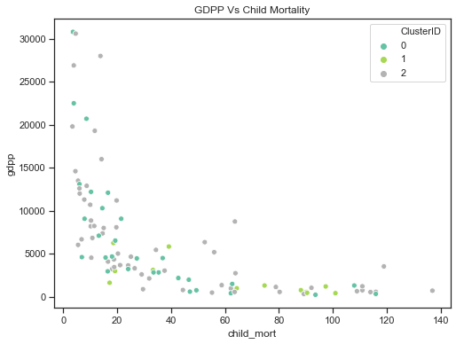

```python
plt.figure(figsize=(8,6))
plt.title('GDPP Vs Child Mortality')
sns.scatterplot(x=kmean2_test2_df['child_mort'],y=kmean2_test2_df['gdpp'],hue=kmean2_test2_df.ClusterID, palette='Set2')
plt.show()
```

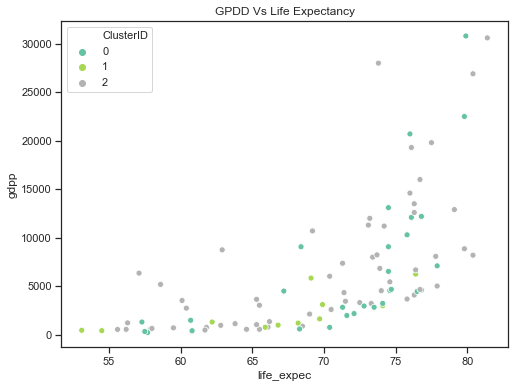

```python
plt.figure(figsize=(8,6))
plt.title('GPDD Vs Life Expectancy')
sns.scatterplot(x=kmean2_test2_df['life_expec'],y=kmean2_test2_df['gdpp'],hue=kmean2_test2_df.ClusterID, palette="Set2")
plt.show()
```

## Child mortality , GDP, Income and Health are four major concerns for analysis

### Conclusion from k-mean cluster analysis:

```python
kmean2_test2_df[kmean2_test2_df['ClusterID']==2]
```

|  | PC1 | PC2 | ClusterID | country | child_mort | exports | health | imports | income | inflation | life_expec | total_fer | gdpp |
| --- | --- | --- | --- | --- | --- | --- | --- | --- | --- | --- | --- | --- | --- |
| 0 | -11180.166271 | 713.612481 | 2 | Afghanistan | 90.2 | 10.00 | 7.58 | 44.9 | 1610 | 9.440 | 56.2 | 5.82 | 553 |
| 1 | -2344.882463 | -1202.984225 | 2 | Albania | 16.6 | 28.00 | 6.55 | 48.6 | 9930 | 4.490 | 76.3 | 1.65 | 4090 |
| 3 | -5958.659572 | 666.908524 | 2 | Angola | 119.0 | 62.30 | 2.85 | 42.9 | 5900 | 22.400 | 60.1 | 6.16 | 3530 |
| 6 | -5484.346297 | -48.178749 | 2 | Armenia | 18.1 | 20.80 | 4.40 | 45.3 | 6700 | 7.770 | 73.3 | 1.69 | 3220 |
| 8 | -10384.064716 | 401.647422 | 2 | Bahamas | 13.8 | 35.00 | 7.89 | 43.7 | 22900 | -0.393 | 73.8 | 1.86 | 28000 |
| 11 | -3874.205286 | 184.806735 | 2 | Barbados | 14.2 | 39.50 | 7.97 | 48.7 | 15300 | 0.321 | 76.7 | 1.78 | 16000 |
| 12 | -10890.367723 | 759.730678 | 2 | Belarus | 5.5 | 51.40 | 5.61 | 64.5 | 16200 | 15.100 | 70.4 | 1.49 | 6030 |
| 13 | -7253.605691 | -315.678240 | 2 | Belize | 18.8 | 58.20 | 5.20 | 57.5 | 7880 | 1.140 | 71.4 | 2.71 | 4340 |
| 14 | -2216.049553 | -657.188519 | 2 | Benin | 111.0 | 23.80 | 4.10 | 37.2 | 1820 | 0.885 | 61.8 | 5.36 | 758 |
| 18 | -11314.462303 | 835.529769 | 2 | Botswana | 52.5 | 43.60 | 8.30 | 51.3 | 13300 | 8.920 | 57.1 | 2.88 | 6350 |
| 19 | -12056.811006 | 939.228644 | 2 | Brazil | 19.8 | 10.70 | 9.01 | 11.8 | 14500 | 8.410 | 74.2 | 1.80 | 11200 |
| 20 | -9885.816108 | 725.361510 | 2 | Bulgaria | 10.8 | 50.20 | 6.87 | 53.0 | 15300 | 1.110 | 73.9 | 1.57 | 6840 |
| 21 | -6142.684612 | 527.661947 | 2 | Burkina Faso | 116.0 | 19.20 | 6.74 | 29.6 | 1430 | 6.810 | 57.9 | 5.87 | 575 |
| 23 | -2400.064103 | -588.290656 | 2 | Cambodia | 44.4 | 54.10 | 5.68 | 59.5 | 2520 | 3.120 | 66.1 | 2.88 | 786 |
| 25 | -12123.905370 | 1112.787801 | 2 | Cape Verde | 26.5 | 32.70 | 4.09 | 61.8 | 5830 | 0.505 | 72.5 | 2.67 | 3310 |
| 26 | -9913.280297 | 634.510976 | 2 | Chile | 8.7 | 37.70 | 7.96 | 31.3 | 19400 | 8.960 | 79.1 | 1.88 | 12900 |
| 31 | -2489.295041 | -402.698645 | 2 | Congo, Rep. | 63.9 | 85.10 | 2.46 | 54.7 | 5190 | 20.700 | 60.4 | 4.95 | 2740 |
| 32 | -3262.437516 | -2379.034536 | 2 | Costa Rica | 10.2 | 33.20 | 10.90 | 35.0 | 13000 | 6.570 | 80.4 | 1.92 | 8200 |
| 33 | -5127.291276 | -582.420625 | 2 | Cote d'Ivoire | 111.0 | 50.60 | 5.30 | 43.3 | 2690 | 5.390 | 56.3 | 5.27 | 1220 |
| 34 | -11376.223069 | 765.312779 | 2 | Croatia | 5.5 | 37.60 | 7.76 | 38.1 | 20100 | 0.821 | 76.3 | 1.55 | 13500 |
| 36 | -4705.357659 | -72.491651 | 2 | Czech Republic | 3.4 | 66.00 | 7.88 | 62.9 | 28300 | -1.430 | 77.5 | 1.51 | 19800 |
| 37 | -11134.116053 | 692.053808 | 2 | Dominican Republic | 34.4 | 22.70 | 6.22 | 33.3 | 11100 | 5.440 | 74.6 | 2.60 | 5450 |
| 38 | -5609.973767 | -277.801264 | 2 | Ecuador | 25.1 | 27.90 | 8.06 | 32.4 | 9350 | 7.470 | 76.7 | 2.66 | 4660 |
| 39 | -9559.174700 | 494.320294 | 2 | Egypt | 29.1 | 21.30 | 4.66 | 26.6 | 9860 | 10.100 | 70.5 | 3.19 | 2600 |
| 41 | -5701.410007 | -372.346964 | 2 | Eritrea | 55.2 | 4.79 | 2.66 | 23.3 | 1420 | 11.600 | 61.7 | 4.61 | 482 |
| 42 | -11468.235384 | 1033.675690 | 2 | Estonia | 4.5 | 75.10 | 6.03 | 68.7 | 22700 | 1.740 | 76.0 | 1.72 | 14600 |
| 43 | -11363.287337 | 835.776492 | 2 | Fiji | 24.1 | 57.80 | 4.86 | 63.9 | 7350 | 4.230 | 65.3 | 2.67 | 3650 |
| 44 | -8433.860828 | -252.555922 | 2 | Gabon | 63.7 | 57.70 | 3.50 | 18.9 | 15400 | 16.600 | 62.9 | 4.08 | 8750 |
| 45 | -4135.457486 | -1136.933878 | 2 | Gambia | 80.3 | 23.80 | 5.69 | 42.7 | 1660 | 4.300 | 65.5 | 5.71 | 562 |
| 48 | -3579.921269 | 393.142321 | 2 | Greece | 3.9 | 22.10 | 10.30 | 30.7 | 28700 | 0.673 | 80.4 | 1.48 | 26900 |
| 49 | -2957.186564 | -1272.137601 | 2 | Grenada | 14.6 | 23.80 | 5.86 | 49.2 | 11200 | 0.480 | 71.3 | 2.24 | 7370 |
| 51 | -10230.747509 | 549.201538 | 2 | Guinea | 109.0 | 30.30 | 4.93 | 43.2 | 1190 | 16.100 | 58.0 | 5.34 | 648 |
| 52 | -10541.083998 | 1409.291517 | 2 | Guinea-Bissau | 114.0 | 14.90 | 8.50 | 35.2 | 1390 | 2.970 | 55.6 | 5.05 | 547 |
| 53 | -10027.807262 | 299.066962 | 2 | Guyana | 37.6 | 51.40 | 5.38 | 79.1 | 5840 | 5.730 | 65.5 | 2.65 | 3040 |
| 55 | -12053.613088 | 1054.549751 | 2 | India | 58.8 | 22.60 | 4.05 | 27.1 | 4410 | 8.980 | 66.2 | 2.60 | 1350 |
| 59 | -11707.971817 | 971.749831 | 2 | Israel | 4.6 | 35.00 | 7.63 | 32.9 | 29600 | 1.770 | 81.4 | 3.03 | 30600 |
| 61 | -9410.445387 | 254.371971 | 2 | Jordan | 21.1 | 48.30 | 8.04 | 69.0 | 9470 | 8.430 | 75.8 | 3.66 | 3680 |
| 63 | -8680.308780 | 264.680518 | 2 | Kenya | 62.2 | 20.70 | 4.75 | 33.6 | 2480 | 2.090 | 62.8 | 4.37 | 967 |
| 65 | -11822.522970 | 1003.767616 | 2 | Kyrgyz Republic | 29.6 | 51.60 | 6.18 | 81.7 | 2790 | 10.000 | 68.5 | 3.10 | 880 |
| 66 | -9206.256411 | -149.634307 | 2 | Lao | 78.9 | 35.40 | 4.47 | 49.3 | 3980 | 9.200 | 63.8 | 3.15 | 1140 |
| 67 | -2909.936217 | 543.938599 | 2 | Latvia | 7.8 | 53.70 | 6.68 | 55.1 | 18300 | -0.812 | 73.1 | 1.36 | 11300 |
| 68 | -10847.316100 | 525.965144 | 2 | Lebanon | 10.3 | 35.80 | 7.03 | 60.2 | 16300 | 0.238 | 79.8 | 1.61 | 8860 |
| 69 | -8719.069800 | -430.527517 | 2 | Liberia | 89.3 | 19.10 | 11.80 | 92.6 | 700 | 5.470 | 60.8 | 5.02 | 327 |
| 71 | -4996.863531 | -380.748389 | 2 | Lithuania | 6.1 | 65.30 | 7.04 | 67.2 | 21100 | 2.380 | 73.2 | 1.50 | 12000 |
| 72 | -7011.845412 | -302.928077 | 2 | Macedonia, FYR | 10.4 | 39.80 | 7.09 | 58.1 | 11400 | 2.040 | 74.0 | 1.47 | 4540 |
| 77 | -11386.610253 | 871.873416 | 2 | Mali | 137.0 | 22.80 | 4.98 | 35.1 | 1870 | 4.370 | 59.5 | 6.55 | 708 |
| 79 | -10456.628493 | 749.372365 | 2 | Mauritius | 15.0 | 51.20 | 6.00 | 62.2 | 15900 | 1.130 | 73.4 | 1.57 | 8000 |
| 81 | -10615.661775 | 1217.015644 | 2 | Montenegro | 6.8 | 37.00 | 9.11 | 62.7 | 14000 | 1.600 | 76.4 | 1.77 | 6680 |
| 85 | -4202.511308 | -1456.958817 | 2 | Namibia | 56.0 | 47.80 | 6.78 | 60.7 | 8460 | 3.560 | 58.6 | 3.60 | 5190 |
| 87 | -11544.252896 | 891.469892 | 2 | Oman | 11.7 | 65.70 | 2.77 | 41.2 | 45300 | 15.600 | 76.1 | 2.90 | 19300 |
| 88 | -6698.069105 | 1214.443171 | 2 | Pakistan | 92.1 | 13.50 | 2.20 | 19.4 | 4280 | 10.900 | 65.3 | 3.85 | 1040 |
| 89 | -1932.272795 | -1433.592060 | 2 | Panama | 19.7 | 70.00 | 8.10 | 78.2 | 15400 | 2.590 | 77.8 | 2.62 | 8080 |
| 91 | -2134.673867 | -923.029992 | 2 | Peru | 20.3 | 27.80 | 5.08 | 23.8 | 9960 | 5.710 | 77.9 | 2.54 | 5020 |
| 92 | -11213.042851 | 788.295201 | 2 | Philippines | 31.9 | 34.80 | 3.61 | 36.6 | 5600 | 4.220 | 69.0 | 3.16 | 2130 |
| 93 | -4714.268957 | -899.067511 | 2 | Poland | 6.0 | 40.10 | 7.46 | 42.1 | 21800 | 1.660 | 76.3 | 1.41 | 12600 |
| 95 | -8690.348065 | 1913.044852 | 2 | Romania | 11.5 | 32.60 | 5.58 | 38.8 | 17800 | 3.530 | 73.7 | 1.59 | 8230 |
| 96 | -8391.543472 | -331.541342 | 2 | Russia | 10.0 | 29.20 | 5.08 | 21.1 | 23100 | 14.200 | 69.2 | 1.57 | 10700 |
| 97 | -8399.799384 | -325.662274 | 2 | Rwanda | 63.6 | 12.00 | 10.50 | 30.0 | 1350 | 2.610 | 64.6 | 4.51 | 563 |
| 98 | -9292.958717 | 489.751313 | 2 | Samoa | 18.9 | 29.20 | 6.47 | 53.1 | 5400 | 1.720 | 71.5 | 4.34 | 3450 |

## Hierarchical clustering

### Single Linkage

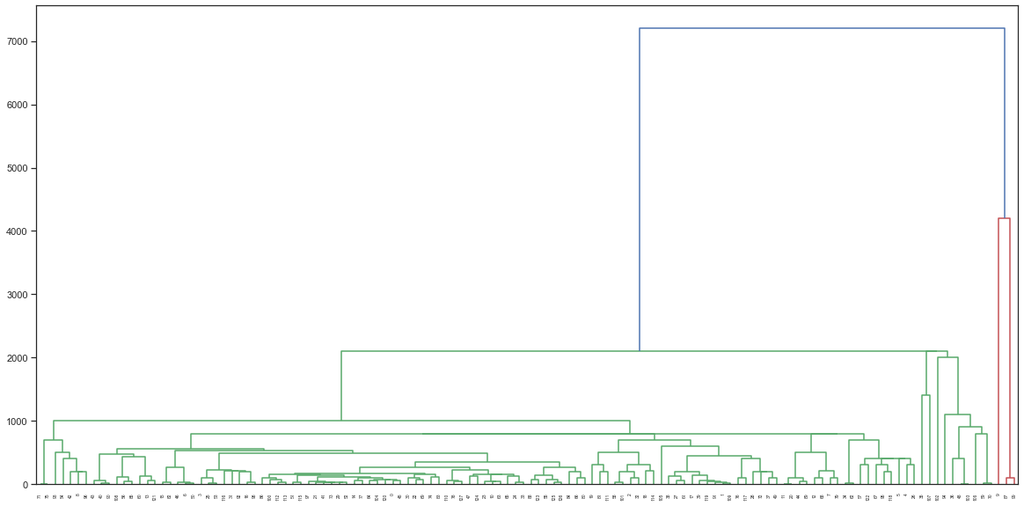

```python
%matplotlib inline
plt.figure(figsize = (20,10))
mergings = linkage(country_df_normalized[['income', 'child_mort']], method="single", metric='euclidean')
dendrogram(mergings)
plt.show()
```

```python
cluster_labels = cut_tree(mergings, n_clusters=3).reshape(-1, )
cluster_labels
```

```
array([0, 0, 0, 0, 0, 0, 0, 0, 0, 1, 0, 0, 0, 0, 0, 0, 0, 0, 0, 0, 0, 0,
       0, 0, 0, 0, 0, 0, 0, 0, 0, 0, 0, 0, 0, 0, 0, 0, 0, 0, 0, 0, 0, 0,
       0, 0, 0, 0, 0, 0, 0, 0, 0, 0, 0, 0, 0, 0, 0, 0, 0, 0, 0, 0, 0, 0,
       0, 0, 0, 0, 0, 0, 0, 0, 0, 0, 0, 0, 0, 0, 0, 0, 0, 0, 0, 0, 0, 2,
       0, 0, 0, 0, 0, 0, 0, 0, 0, 0, 0, 2, 0, 0, 0, 0, 0, 0, 0, 0, 0, 0,
       0, 0, 0, 0, 0, 0, 0, 0, 0, 0, 0, 0, 0, 0, 0, 0, 0, 0])
```

```python
unique_elements, counts_elements = np.unique(cluster_labels, return_counts=True)
print("Frequency of unique values of the said array:")
print(np.asarray((unique_elements, counts_elements)))
```

```
Frequency of unique values of the said array:
[[  0   1   2]
 [125   1   2]]
```

## Complete Linkage

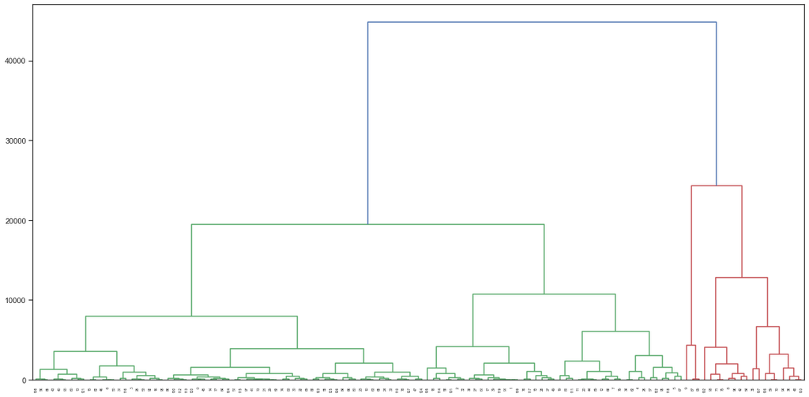

```python
# complete linkage
%matplotlib inline
plt.figure(figsize = (20,10))
mergings = linkage(country_df_normalized[['income', 'child_mort']], method="complete", metric='euclidean')
dendrogram(mergings)
plt.show()
```

```python
cluster_labels = cut_tree(mergings, n_clusters=3).reshape(-1, )
cluster_labels
```

```
array([0, 0, 0, 0, 0, 0, 0, 0, 1, 2, 0, 0, 0, 0, 0, 0, 0, 0, 0, 0, 0, 0,
       0, 0, 0, 0, 0, 0, 0, 0, 0, 0, 0, 0, 0, 1, 1, 0, 0, 0, 0, 0, 1, 0,
       0, 0, 0, 0, 1, 0, 0, 0, 0, 0, 1, 0, 0, 0, 0, 1, 0, 0, 0, 0, 0, 0,
       0, 0, 0, 0, 1, 1, 0, 0, 0, 1, 0, 0, 0, 0, 0, 0, 0, 0, 0, 0, 0, 2,
       0, 0, 0, 0, 0, 1, 1, 0, 1, 0, 0, 2, 0, 0, 1, 1, 0, 0, 1, 1, 0, 0,
       0, 0, 0, 0, 0, 0, 0, 0, 0, 0, 0, 0, 0, 0, 0, 0, 0, 0])
```

```python
unique_elements, counts_elements = np.unique(cluster_labels, return_counts=True)
print("Frequency of unique values of the said array:")
print(np.asarray((unique_elements, counts_elements)))
```

```
Frequency of unique values of the said array:
[[  0   1   2]
 [108  17   3]]
```

## Analyze clusters based on 3 variables [gdpp, child_mort, income]

```python
country_df_normalized['cluster_labels'] = cluster_labels
country_df_normalized.head(10)
```

|  | country | child_mort | exports | health | imports | income | inflation | life_expec | total_fer | gdpp | cluster_labels |
| --- | --- | --- | --- | --- | --- | --- | --- | --- | --- | --- | --- |
| 0 | Afghanistan | 90.2 | 10.0 | 7.58 | 44.9 | 1610 | 9.440 | 56.2 | 5.82 | 553 | 0 |
| 1 | Albania | 16.6 | 28.0 | 6.55 | 48.6 | 9930 | 4.490 | 76.3 | 1.65 | 4090 | 0 |
| 2 | Algeria | 27.3 | 38.4 | 4.17 | 31.4 | 12900 | 16.100 | 76.5 | 2.89 | 4460 | 0 |
| 3 | Angola | 119.0 | 62.3 | 2.85 | 42.9 | 5900 | 22.400 | 60.1 | 6.16 | 3530 | 0 |
| 4 | Antigua and Barbuda | 10.3 | 45.5 | 6.03 | 58.9 | 19100 | 1.440 | 76.8 | 2.13 | 12200 | 0 |
| 5 | Argentina | 14.5 | 18.9 | 8.10 | 16.0 | 18700 | 20.900 | 75.8 | 2.37 | 10300 | 0 |
| 6 | Armenia | 18.1 | 20.8 | 4.40 | 45.3 | 6700 | 7.770 | 73.3 | 1.69 | 3220 | 0 |
| 9 | Azerbaijan | 39.2 | 54.3 | 5.88 | 20.7 | 16000 | 13.800 | 69.1 | 1.92 | 5840 | 0 |
| 10 | Bahamas | 13.8 | 35.0 | 7.89 | 43.7 | 22900 | -0.393 | 73.8 | 1.86 | 28000 | 1 |
| 11 | Bahrain | 8.6 | 69.5 | 4.97 | 50.9 | 41100 | 7.440 | 76.0 | 2.16 | 20700 | 2 |

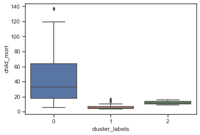

```python
sns.boxplot(data=country_df_normalized, x='cluster_labels', y='child_mort')
```

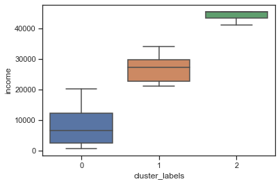

```python
sns.boxplot(data=country_df_normalized, x='cluster_labels', y='income')
```

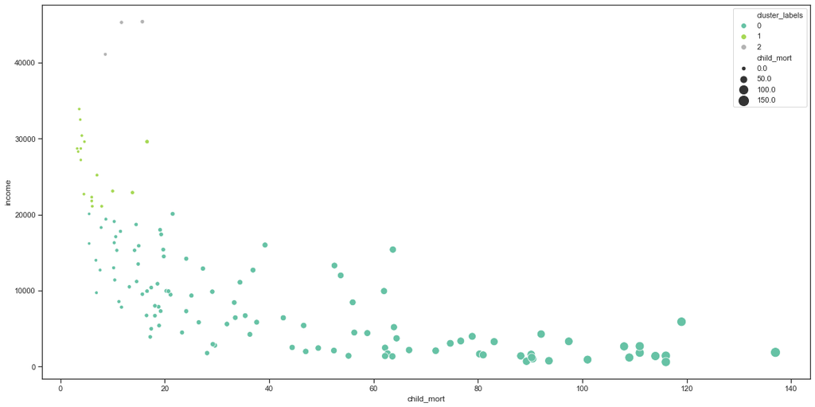

```python
plt.figure(figsize = (20,10))
ax = sns.scatterplot(data=country_df_normalized, x='child_mort', y='income', \
                     hue='cluster_labels',  \
                     size='child_mort',\
                     sizes=(20, 200),\
                     palette="Set2")
```

```python
country_df.info()
```

```
<class 'pandas.core.frame.DataFrame'>
RangeIndex: 167 entries, 0 to 166
Data columns (total 10 columns):
country       167 non-null object
child_mort    167 non-null float64
exports       167 non-null float64
health        167 non-null float64
imports       167 non-null float64
income        167 non-null int64
inflation     167 non-null float64
life_expec    167 non-null float64
total_fer     167 non-null float64
gdpp          167 non-null int64
dtypes: float64(7), int64(2), object(1)
memory usage: 13.2+ KB
```

```python
country_df_normalized.head(10)
```

|  | country | child_mort | exports | health | imports | income | inflation | life_expec | total_fer | gdpp | cluster_labels |
| --- | --- | --- | --- | --- | --- | --- | --- | --- | --- | --- | --- |
| 0 | Afghanistan | 90.2 | 10.0 | 7.58 | 44.9 | 1610 | 9.440 | 56.2 | 5.82 | 553 | 0 |
| 1 | Albania | 16.6 | 28.0 | 6.55 | 48.6 | 9930 | 4.490 | 76.3 | 1.65 | 4090 | 0 |
| 2 | Algeria | 27.3 | 38.4 | 4.17 | 31.4 | 12900 | 16.100 | 76.5 | 2.89 | 4460 | 0 |
| 3 | Angola | 119.0 | 62.3 | 2.85 | 42.9 | 5900 | 22.400 | 60.1 | 6.16 | 3530 | 0 |
| 4 | Antigua and Barbuda | 10.3 | 45.5 | 6.03 | 58.9 | 19100 | 1.440 | 76.8 | 2.13 | 12200 | 0 |
| 5 | Argentina | 14.5 | 18.9 | 8.10 | 16.0 | 18700 | 20.900 | 75.8 | 2.37 | 10300 | 0 |
| 6 | Armenia | 18.1 | 20.8 | 4.40 | 45.3 | 6700 | 7.770 | 73.3 | 1.69 | 3220 | 0 |
| 9 | Azerbaijan | 39.2 | 54.3 | 5.88 | 20.7 | 16000 | 13.800 | 69.1 | 1.92 | 5840 | 0 |
| 10 | Bahamas | 13.8 | 35.0 | 7.89 | 43.7 | 22900 | -0.393 | 73.8 | 1.86 | 28000 | 1 |
| 11 | Bahrain | 8.6 | 69.5 | 4.97 | 50.9 | 41100 | 7.440 | 76.0 | 2.16 | 20700 | 2 |

## Report back 5 countries in direst need

### Based on our analysis, the 5 countries which need the financial aid the most are as following

```python
country_df_normalized.sort_values(['child_mort', 'income'], ascending=False)
```

|  | country | child_mort | exports | health | imports | income | inflation | life_expec | total_fer | gdpp | cluster_labels |
| --- | --- | --- | --- | --- | --- | --- | --- | --- | --- | --- | --- |
| 97 | Mali | 137.0 | 22.800 | 4.98 | 35.1000 | 1870 | 4.370 | 59.5 | 6.55 | 708 | 0 |
| 3 | Angola | 119.0 | 62.300 | 2.85 | 42.9000 | 5900 | 22.400 | 60.1 | 6.16 | 3530 | 0 |
| 25 | Burkina Faso | 116.0 | 19.200 | 6.74 | 29.6000 | 1430 | 6.810 | 57.9 | 5.87 | 575 | 0 |
| 37 | Congo, Dem. Rep. | 116.0 | 41.100 | 7.91 | 49.6000 | 609 | 20.800 | 57.5 | 6.54 | 334 | 0 |
| 64 | Guinea-Bissau | 114.0 | 14.900 | 8.50 | 35.2000 | 1390 | 2.970 | 55.6 | 5.05 | 547 | 0 |
| 40 | Cote d'Ivoire | 111.0 | 50.600 | 5.30 | 43.3000 | 2690 | 5.390 | 56.3 | 5.27 | 1220 | 0 |
| 17 | Benin | 111.0 | 23.800 | 4.10 | 37.2000 | 1820 | 0.885 | 61.8 | 5.36 | 758 | 0 |
| 63 | Guinea | 109.0 | 30.300 | 4.93 | 43.2000 | 1190 | 16.100 | 58.0 | 5.34 | 648 | 0 |
| 28 | Cameroon | 108.0 | 22.200 | 5.13 | 27.0000 | 2660 | 1.910 | 57.3 | 5.11 | 1310 | 0 |
| 106 | Mozambique | 101.0 | 31.500 | 5.21 | 46.2000 | 918 | 7.640 | 54.5 | 5.56 | 419 | 0 |
| 99 | Mauritania | 97.4 | 50.700 | 4.41 | 61.2000 | 3320 | 18.900 | 68.2 | 4.98 | 1200 | 0 |
| 26 | Burundi | 93.6 | 8.920 | 11.60 | 39.2000 | 764 | 12.300 | 57.7 | 6.26 | 231 | 0 |
| 116 | Pakistan | 92.1 | 13.500 | 2.20 | 19.4000 | 4280 | 10.900 | 65.3 | 3.85 | 1040 | 0 |
| 94 | Malawi | 90.5 | 22.800 | 6.59 | 34.9000 | 1030 | 12.100 | 53.1 | 5.31 | 459 | 0 |
| 150 | Togo | 90.3 | 40.200 | 7.65 | 57.3000 | 1210 | 1.180 | 58.7 | 4.87 | 488 | 0 |
| 0 | Afghanistan | 90.2 | 10.000 | 7.58 | 44.9000 | 1610 | 9.440 | 56.2 | 5.82 | 553 | 0 |
| 88 | Liberia | 89.3 | 19.100 | 11.80 | 92.6000 | 700 | 5.470 | 60.8 | 5.02 | 327 | 0 |
| 36 | Comoros | 88.2 | 16.500 | 4.51 | 51.7000 | 1410 | 3.870 | 65.9 | 4.75 | 769 | 0 |
| 166 | Zambia | 83.1 | 37.000 | 5.89 | 30.9000 | 3280 | 14.000 | 52.0 | 5.40 | 1460 | 0 |
| 155 | Uganda | 81.0 | 17.100 | 9.01 | 28.6000 | 1540 | 10.600 | 56.8 | 6.15 | 595 | 0 |
| 56 | Gambia | 80.3 | 23.800 | 5.69 | 42.7000 | 1660 | 4.300 | 65.5 | 5.71 | 562 | 0 |
| 84 | Lao | 78.9 | 35.400 | 4.47 | 49.3000 | 3980 | 9.200 | 63.8 | 3.15 | 1140 | 0 |
| 142 | Sudan | 76.7 | 19.700 | 6.32 | 17.2000 | 3370 | 19.600 | 66.3 | 4.88 | 1480 | 0 |
| 59 | Ghana | 74.7 | 29.500 | 5.22 | 45.9000 | 3060 | 16.600 | 62.2 | 4.27 | 1310 | 0 |
| 147 | Tanzania | 71.9 | 18.700 | 6.01 | 29.1000 | 2090 | 9.250 | 59.3 | 5.43 | 702 | 0 |
| 129 | Senegal | 66.8 | 24.900 | 5.66 | 40.3000 | 2180 | 1.850 | 64.0 | 5.06 | 1000 | 0 |
| 107 | Myanmar | 64.4 | 0.109 | 1.97 | 0.0659 | 3720 | 7.040 | 66.8 | 2.41 | 988 | 0 |
| 38 | Congo, Rep. | 63.9 | 85.100 | 2.46 | 54.7000 | 5190 | 20.700 | 60.4 | 4.95 | 2740 | 0 |
| 55 | Gabon | 63.7 | 57.700 | 3.50 | 18.9000 | 15400 | 16.600 | 62.9 | 4.08 | 8750 | 0 |
| 126 | Rwanda | 63.6 | 12.000 | 10.50 | 30.0000 | 1350 | 2.610 | 64.6 | 4.51 | 563 | 0 |
| ... | ... | ... | ... | ... | ... | ... | ... | ... | ... | ... | ... |
| 140 | Sri Lanka | 11.2 | 19.600 | 2.94 | 26.8000 | 8560 | 22.800 | 74.4 | 2.20 | 2810 | 0 |
| 24 | Bulgaria | 10.8 | 50.200 | 6.87 | 53.0000 | 15300 | 1.110 | 73.9 | 1.57 | 6840 | 0 |
| 160 | Uruguay | 10.6 | 26.300 | 8.35 | 25.4000 | 17100 | 4.910 | 76.4 | 2.08 | 11900 | 0 |
| 92 | Macedonia, FYR | 10.4 | 39.800 | 7.09 | 58.1000 | 11400 | 2.040 | 74.0 | 1.47 | 4540 | 0 |
| 4 | Antigua and Barbuda | 10.3 | 45.500 | 6.03 | 58.9000 | 19100 | 1.440 | 76.8 | 2.13 | 12200 | 0 |
| 86 | Lebanon | 10.3 | 35.800 | 7.03 | 60.2000 | 16300 | 0.238 | 79.8 | 1.61 | 8860 | 0 |
| 39 | Costa Rica | 10.2 | 33.200 | 10.90 | 35.0000 | 13000 | 6.570 | 80.4 | 1.92 | 8200 | 0 |
| 125 | Russia | 10.0 | 29.200 | 5.08 | 21.1000 | 23100 | 14.200 | 69.2 | 1.57 | 10700 | 1 |
| 33 | Chile | 8.7 | 37.700 | 7.96 | 31.3000 | 19400 | 8.960 | 79.1 | 1.88 | 12900 | 0 |
| 11 | Bahrain | 8.6 | 69.500 | 4.97 | 50.9000 | 41100 | 7.440 | 76.0 | 2.16 | 20700 | 2 |
| 95 | Malaysia | 7.9 | 86.900 | 4.39 | 71.0000 | 21100 | 7.270 | 74.5 | 2.15 | 9070 | 1 |
| 85 | Latvia | 7.8 | 53.700 | 6.68 | 55.1000 | 18300 | -0.812 | 73.1 | 1.36 | 11300 | 0 |
| 130 | Serbia | 7.6 | 32.900 | 10.40 | 47.9000 | 12700 | 5.880 | 74.7 | 1.40 | 5410 | 0 |
| 134 | Slovak Republic | 7.0 | 76.300 | 8.79 | 77.8000 | 25200 | 0.485 | 75.5 | 1.43 | 16600 | 1 |
| 20 | Bosnia and Herzegovina | 6.9 | 29.700 | 11.10 | 51.3000 | 9720 | 1.400 | 76.8 | 1.31 | 4610 | 0 |
| 104 | Montenegro | 6.8 | 37.000 | 9.11 | 62.7000 | 14000 | 1.600 | 76.4 | 1.77 | 6680 | 0 |
| 90 | Lithuania | 6.1 | 65.300 | 7.04 | 67.2000 | 21100 | 2.380 | 73.2 | 1.50 | 12000 | 1 |
| 67 | Hungary | 6.0 | 81.800 | 7.33 | 76.5000 | 22300 | 2.330 | 74.5 | 1.25 | 13100 | 1 |
| 121 | Poland | 6.0 | 40.100 | 7.46 | 42.1000 | 21800 | 1.660 | 76.3 | 1.41 | 12600 | 1 |
| 41 | Croatia | 5.5 | 37.600 | 7.76 | 38.1000 | 20100 | 0.821 | 76.3 | 1.55 | 13500 | 0 |
| 14 | Belarus | 5.5 | 51.400 | 5.61 | 64.5000 | 16200 | 15.100 | 70.4 | 1.49 | 6030 | 0 |
| 74 | Israel | 4.6 | 35.000 | 7.63 | 32.9000 | 29600 | 1.770 | 81.4 | 3.03 | 30600 | 1 |
| 51 | Estonia | 4.5 | 75.100 | 6.03 | 68.7000 | 22700 | 1.740 | 76.0 | 1.72 | 14600 | 1 |
| 138 | South Korea | 4.1 | 49.400 | 6.93 | 46.2000 | 30400 | 3.160 | 80.1 | 1.23 | 22100 | 1 |
| 60 | Greece | 3.9 | 22.100 | 10.30 | 30.7000 | 28700 | 0.673 | 80.4 | 1.48 | 26900 | 1 |
| 122 | Portugal | 3.9 | 29.900 | 11.00 | 37.4000 | 27200 | 0.643 | 79.8 | 1.39 | 22500 | 1 |
| 139 | Spain | 3.8 | 25.500 | 9.54 | 26.8000 | 32500 | 0.160 | 81.9 | 1.37 | 30700 | 1 |
| 42 | Cyprus | 3.6 | 50.200 | 5.97 | 57.5000 | 33900 | 2.010 | 79.9 | 1.42 | 30800 | 1 |
| 43 | Czech Republic | 3.4 | 66.000 | 7.88 | 62.9000 | 28300 | -1.430 | 77.5 | 1.51 | 19800 | 1 |
| 135 | Slovenia | 3.2 | 64.300 | 9.41 | 62.9000 | 28700 | -0.987 | 79.5 | 1.57 | 23400 | 1 |

128 rows × 11 columns